# IC12: Summary of Data Analysis: R3, R6, R4a, R4b, & R4c

Case 31: Employees Federal Credit Union

Author

Kevin Bachez

Published

November 15, 2026

# Research Questions & Analysis Plan

Table 1: Data analysis table for R3, R6, R4a, R4b, and R4c

| RQ | Research question | Variables | Scale | Statistical test |
| --- | --- | --- | --- | --- |
| R3 | What are members’ attitudes toward the proficiency of CU employees? | Q3 – Q6; Att_employee | Interval | Descriptive statistics, one-sample t-test |
| R6 | How effectively is the credit union operated? | Q9r, Q10r, Q31 – Q34, Q37r | Interval | Descriptive statistics, one-sample t-test |
| R6 |  | Q11, Q12rc | Nominal | Frequencies, chi-square goodness-of-fit test |
| R4a | Do HQ-area and other members differ in attitudes toward employee proficiency? | Q38 (IV); Att_employee (DV) | Nominal; Interval | Descriptive statistics, independent-groups t-test |
| R4b | Do HQ-area and other members differ in awareness of services? | Q38 (IV); Q13r – Q26r (DV) | Nominal; Ordinal | Cross-tabulation, chi-square test of independence |
| R4c | Do HQ-area and other members differ in views of operational effectiveness? | Q38 (IV); Q9r, Q10r, Q31 – Q34, Q37r (DV) | Nominal; Interval | Descriptive statistics, independent-groups t-tests |
| R4c |  | Q38 (IV); Q11, Q12rc (DV) | Nominal; Nominal | Cross-tabulation, chi-square test of independence |

The sample has 128 credit union members: 57 live in the headquarters area and 71 live elsewhere. Following Case Exhibit 31.2, “No Opinion” and “No answer” responses are treated as missing, so all percentages are **valid percentages**.

**Measurement decisions from the previous activity.** The reliability and factor analysis showed that Q3 – Q6 form one reliable scale, so R3 and R4a use the composite **Att_employee** (the average of Q3 – Q6). The operations items in R6 and R4c did not form a reliable scale, so each item is analyzed on its own.

# R3: Attitudes Toward Employee Proficiency

## R3: Descriptive Statistics (Q3 – Q6)

Table 2: Agreement with statements about credit union employees (valid %)

| Item | Strongly Disagree | Disagree | Uncertain | Agree | Strongly Agree |
| --- | --- | --- | --- | --- | --- |
| Q3: Courteous | 0 | 0.0 | 10.2 | 44.5 | 45.3 |
| Q4: Helpful | 0 | 0.8 | 10.9 | 44.5 | 43.8 |
| Q5: Professional | 0 | 0.0 | 18.0 | 56.2 | 25.8 |
| Q6: Always available | 0 | 3.1 | 18.0 | 46.9 | 32.0 |

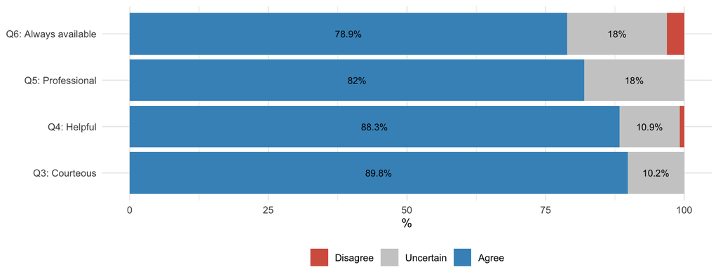

Figure 1: Agreement with statements about credit union employees (Q3 – Q6)

## R3: One-Sample t-tests (Att_employee & Q3 – Q6)

Table 3: One-sample t-tests for employee proficiency (test value = 3, Uncertain)

| Item | n | Mean | SD | Test value | t | df | p |
| --- | --- | --- | --- | --- | --- | --- | --- |
| Att_employee: Average of Q3 – Q6 | 128 | 4.21 | 0.59 | 3 | 22.95 | 127 | <0.001 |
| Q3: Courteous | 128 | 4.35 | 0.66 | 3 | 23.20 | 127 | <0.001 |
| Q4: Helpful | 128 | 4.31 | 0.70 | 3 | 21.34 | 127 | <0.001 |
| Q5: Professional | 128 | 4.08 | 0.66 | 3 | 18.50 | 127 | <0.001 |
| Q6: Always available | 128 | 4.08 | 0.79 | 3 | 15.44 | 127 | <0.001 |

# R6: Operational Effectiveness

## R6: Descriptive Statistics & One-Sample t-tests (Interval Items)

Table 4: Operational effectiveness items: descriptive statistics and one-sample t-tests

| Item | n | Mean | SD | Test value | t | df | p |
| --- | --- | --- | --- | --- | --- | --- | --- |
| Q9r: Statement frequency (3 = About right) | 128 | 2.77 | 0.42 | 3.0 | -6.10 | 127 | <0.001 |
| Q10r: Statement accuracy (4 = Excellent) | 128 | 3.47 | 0.64 | 2.5 | 17.15 | 127 | <0.001 |
| Q31: Personnel keep financial info confidential | 128 | 3.95 | 0.68 | 3.0 | 15.74 | 127 | <0.001 |
| Q32: Prompt in processing loan applications | 128 | 3.72 | 0.79 | 3.0 | 10.25 | 127 | <0.001 |
| Q33: Services meet members’ needs | 128 | 3.59 | 0.68 | 3.0 | 9.87 | 127 | <0.001 |
| Q34: Loan applications simple and easy | 128 | 3.46 | 0.78 | 3.0 | 6.66 | 127 | <0.001 |
| Q37r: Overall management & operation (5 = Excellent) | 121 | 4.07 | 0.73 | 3.0 | 16.13 | 120 | <0.001 |

Test values are the scale midpoints, except for Q9r. For Q9r, “About right” (3) is the ideal answer, so it is the benchmark.

## R6: Descriptive Statistics, Agreement with Q31 – Q34

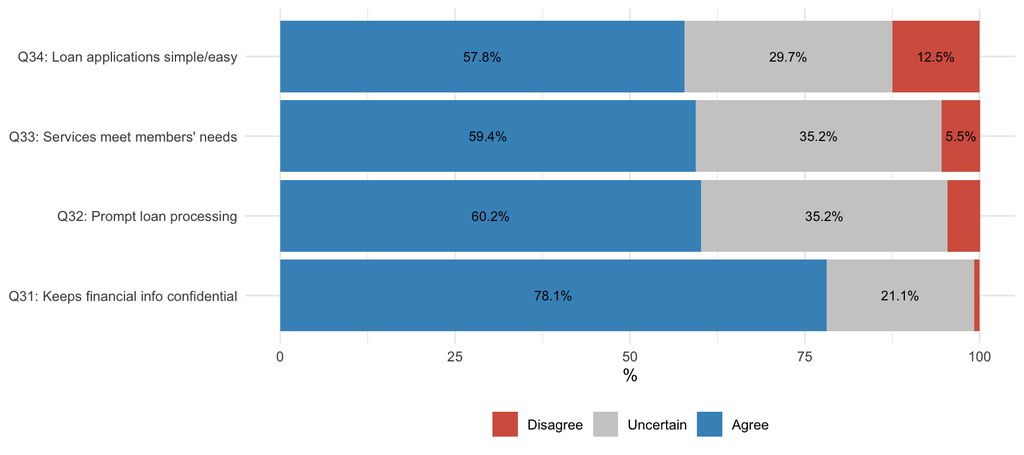

Figure 2: Agreement with statements about credit union operations (Q31–Q34)

## R6: Descriptive Statistics & Chi-square Goodness-of-Fit Tests (Q11, Q12rc)

Table 5: Statements easy to understand? (Q11)

| Response | n | Valid % |
| --- | --- | --- |
| Yes | 125 | 97.7 |
| No | 3 | 2.3 |

Table 6: Accounts kept confidential? (Q12rc, No answer excluded)

| Response | n | Valid % |
| --- | --- | --- |
| Yes | 74 | 69.8 |
| No | 32 | 30.2 |

Table 7: Chi-square goodness-of-fit tests for nominal items (equal proportions expected)

| Item | Chi-square | df | p |
| --- | --- | --- | --- |
| Q11: Statements easy to understand | 116.28 | 1 | <0.001 |
| Q12rc: Accounts kept confidential | 16.64 | 1 | <0.001 |

## R6: Insight

Three areas need attention:

- **Loan processes are rated lowest.** Only 57.8% agree that loan applications are simple and easy, and 60.2% that loans are processed promptly. Both are still above neutral (p < .001), but this fits the R2 finding from the previous report that members see no loan rate advantage here.
- **Statements may come too rarely.** 22.7% of members say statements come “not often enough,” so frequency falls short of the “about right” ideal (M = 2.77, t(127) = −6.10, p < .001).
- **Confidentiality is not universal.** Among members who answered, 69.8% say their accounts are kept confidential, but almost a third (30.2%) say they are not (χ²(1) = 16.64, p < .001; Table 6). Another 22 members gave no answer.

# R4: Headquarters Area vs. Elsewhere

## R4: Sample by Residence (Q38)

Table 8: Members by area of residence (Q38)

| Response | n | Valid % |
| --- | --- | --- |
| HQ area | 57 | 44.5 |
| Elsewhere | 71 | 55.5 |

## R4a: Descriptive Statistics (Att_employee by Residence)

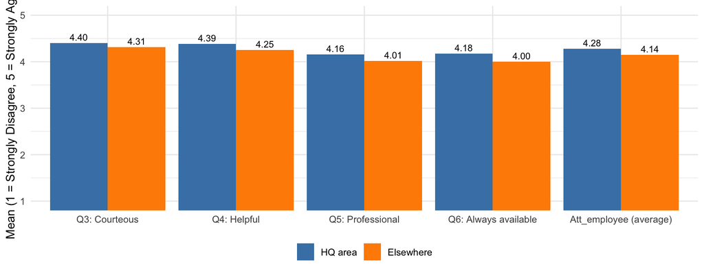

Figure 3: Attitude toward employee proficiency by residence (mean of Q3 – Q6)

## R4a: Independent-Groups t-test (Att_employee)

Table 9: Independent-groups t-test: attitude toward employee proficiency by residence

| Item | HQ area M (SD) | Elsewhere M (SD) | Levene p | Test | t | df | p |
| --- | --- | --- | --- | --- | --- | --- | --- |
| Att_employee: Average of Q3 – Q6 | 4.28 (0.57) | 4.14 (0.61) | 0.84 | Pooled | 1.29 | 126 | 0.198 |

## R4a: Insight

**Insight.** Members feel the same way about employees wherever they live. Both groups rate staff very positively. Members in the headquarters area score slightly higher (M = 4.28) than those elsewhere (M = 4.14), but the gap is small and not significant (t(126) = 1.29, p = .198; Table 9, Figure 3). Members living away from headquarters do **not** feel that employees are less courteous, helpful, professional, or available to them. The strength found in R3 holds for all members.

## R4b: Cross-Tabulation (Awareness of Services by Residence)

Table 10: Awareness of credit union services by residence (row % within each group)

| Item | Service | HQ area: Unaware | HQ area: Aware, not used | HQ area: Aware & used | Elsewhere: Unaware | Elsewhere: Aware, not used | Elsewhere: Aware & used |
| --- | --- | --- | --- | --- | --- | --- | --- |
| Q13r | Regular share account | 59.6 | 28.1 | 12.3 | 69.0 | 22.5 | 8.5 |
| Q14r | Special subaccounts | 38.6 | 54.4 | 7.0 | 33.8 | 54.9 | 11.3 |
| Q15r | Christmas club account | 29.8 | 61.4 | 8.8 | 35.2 | 56.3 | 8.5 |
| Q16r | Individual Retirement Account | 28.1 | 47.4 | 24.6 | 26.8 | 52.1 | 21.1 |
| Q17r | MasterCard credit card | 17.5 | 38.6 | 43.9 | 7.0 | 49.3 | 43.7 |
| Q18r | Signature loans | 7.0 | 78.9 | 14.0 | 1.4 | 83.1 | 15.5 |
| Q19r | New car loans | 3.5 | 78.9 | 17.5 | 4.2 | 76.1 | 19.7 |
| Q20r | Late model car loans | 14.0 | 75.4 | 10.5 | 5.6 | 83.1 | 11.3 |
| Q21r | Older model car loans | 26.3 | 66.7 | 7.0 | 25.4 | 63.4 | 11.3 |
| Q22r | Household goods/appliance loans | 33.3 | 57.9 | 8.8 | 25.4 | 66.2 | 8.5 |
| Q23r | Recreational loans | 38.6 | 52.6 | 8.8 | 46.5 | 42.3 | 11.3 |
| Q24r | Share collateralized loans | 54.4 | 43.9 | 1.8 | 53.5 | 45.1 | 1.4 |
| Q25r | IRA loans | 63.2 | 36.8 | 0.0 | 59.2 | 35.2 | 5.6 |
| Q26r | Line of credit loans | 0.0 | 64.9 | 35.1 | 0.0 | 60.6 | 39.4 |

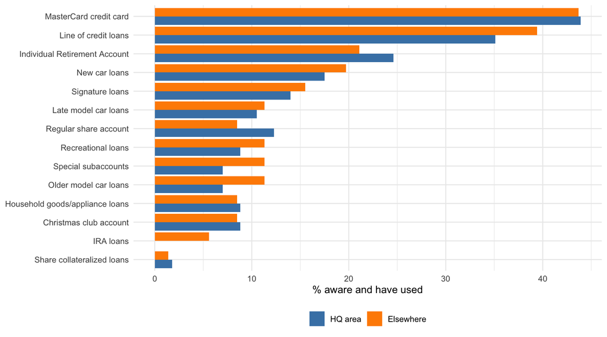

Figure 4: Percent of members who have used each service, by residence

## R4b: Chi-square Tests of Independence (Q13r – Q26r)

Table 11: Chi-square tests of independence: awareness of services by residence

| Item | Chi-square | df | p | Min. expected | Fisher p |
| --- | --- | --- | --- | --- | --- |
| Q13r: Regular share account | 1.27 | 2 | 0.529 | 5.8 | 0.543 |
| Q14r: Special subaccounts | 0.81 | 2 | 0.666 | 5.3 | 0.722 |
| Q15r: Christmas club account | 0.42 | 2 | 0.81 | 4.9 | 0.86 |
| Q16r: Individual Retirement Account | 0.33 | 2 | 0.849 | 12.9 | 0.869 |
| Q17r: MasterCard credit card | 3.79 | 2 | 0.15 | 6.7 | 0.158 |
| Q18r: Signature loans | 2.66 | 2 | 0.265 | 2.2 | 0.319 |
| Q19r: New car loans | 0.16 | 2 | 0.925 | 2.2 | 0.938 |
| Q20r: Late model car loans | 2.63 | 2 | 0.269 | 5.3 | 0.287 |
| Q21r: Older model car loans | 0.67 | 2 | 0.714 | 5.3 | 0.732 |
| Q22r: Household goods/appliance loans | 1.05 | 2 | 0.592 | 4.9 | 0.622 |
| Q23r: Recreational loans | 1.38 | 2 | 0.502 | 5.8 | 0.519 |
| Q24r: Share collateralized loans | 0.04 | 2 | 0.981 | 0.9 | 1 |
| Q25r: IRA loans | 3.32 | 2 | 0.19 | 1.8 | 0.242 |
| Q26r: Line of credit loans | 0.26 | 1 | 0.613 | 21.4 | 0.714 |

Several services have cells with expected counts below 5, so Fisher’s exact test is shown as a check. It leads to the same conclusion as the chi-square test for every service.

## R4b: Insight

**Insight.** Where members live does not change what they know about, or use, at the credit union. Awareness profiles are very similar in both groups, and no service shows a significant difference (all p ≥ .15; Table 11). A few gaps look larger, but they are not reliable with groups this size. For example, more HQ-area members are unaware of the MasterCard (17.5% vs. 7.0%), yet the share who have used it is almost identical (43.9% vs. 43.7%; Table 10, Figure 4). The awareness problems found in R5, such as IRA loans and share collateralized loans, are shared by **all** members. They are not a result of living away from headquarters. Communication about services should therefore target the whole membership rather than one location.

## R4c: Descriptive Statistics & Independent-Groups t-tests (Interval Items)

Table 12: Independent-groups t-tests: operational effectiveness by residence

| Item | HQ area M (SD) | Elsewhere M (SD) | Levene p | Test | t | df | p |
| --- | --- | --- | --- | --- | --- | --- | --- |
| Q9r: Statement frequency (3 = About right) | 2.79 (0.41) | 2.76 (0.43) | 0.701 | Pooled | 0.39 | 126.0 | 0.701 |
| Q10r: Statement accuracy (4 = Excellent) | 3.49 (0.66) | 3.45 (0.63) | 0.723 | Pooled | 0.36 | 126.0 | 0.723 |
| Q31: Personnel keep financial info confidential | 4.05 (0.67) | 3.86 (0.68) | 0.647 | Pooled | 1.61 | 126.0 | 0.11 |
| Q32: Prompt in processing loan applications | 3.68 (0.81) | 3.75 (0.79) | 0.699 | Pooled | -0.44 | 126.0 | 0.661 |
| Q33: Services meet members’ needs | 3.60 (0.73) | 3.59 (0.65) | 0.288 | Pooled | 0.04 | 126.0 | 0.968 |
| Q34: Loan applications simple and easy | 3.28 (0.92) | 3.61 (0.62) | 0.001 | Welch | -2.28 | 94.2 | 0.0249 |
| Q37r: Overall management & operation | 4.02 (0.66) | 4.10 (0.78) | 0.729 | Pooled | -0.64 | 119.0 | 0.52 |

When Levene’s test is significant (p < .05), the Welch t-test (unequal variances) is reported.

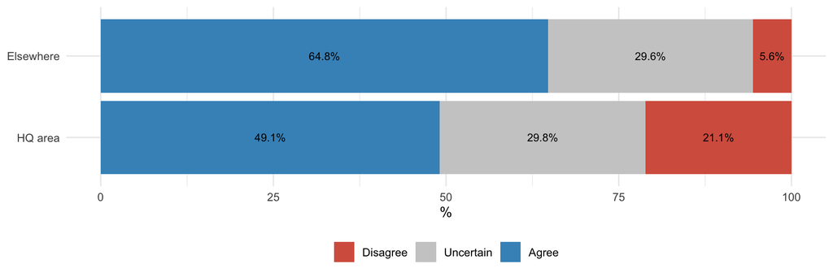

Figure 5: Agreement that loan applications are simple and easy (Q34) by residence

## R4c: Cross-Tabulation & Chi-square Tests of Independence (Q11, Q12rc)

Table 13: Nominal operations items by residence (row % within each group)

| Item | Residence | Yes % | No % |
| --- | --- | --- | --- |
| Q11: Statements easy to understand | HQ area | 96.5 | 3.5 |
| Q11: Statements easy to understand | Elsewhere | 98.6 | 1.4 |
| Q12rc: Accounts kept confidential | HQ area | 63.3 | 36.7 |
| Q12rc: Accounts kept confidential | Elsewhere | 75.4 | 24.6 |

Table 14: Chi-square tests of independence: nominal operations items by residence

| Item | Chi-square | df | p | Min. expected | Fisher p |
| --- | --- | --- | --- | --- | --- |
| Q11: Statements easy to understand | 0.61 | 1 | 0.435 | 1.3 | 0.585 |
| Q12rc: Accounts kept confidential | 1.85 | 1 | 0.173 | 14.8 | 0.206 |

## R4c: Insight

**Insight.** Members in both locations judge the credit union’s operations about the same, with one exception: **the loan application**. Members in the headquarters area find loan applications *less* simple and easy (M = 3.28) than members elsewhere (M = 3.61). The difference is significant (Welch t(94.2) = −2.28, p = .025; Table 12). Only 49.1% of HQ-area members agree the forms are simple, compared with 64.8% elsewhere, and 21.1% of HQ-area members disagree, compared with 5.6% (Figure 5).

On every other measure, the two groups do not differ (all p > .10; Table 12, Table 14). That includes statement frequency and accuracy, confidentiality, loan promptness, meeting needs, and overall management. HQ-area members are somewhat less likely to say their accounts are kept confidential (63.3% vs. 75.4%), but the difference is not significant (χ²(1) = 1.85, p = .173; Table 13, Table 14).

The loan application was already the weakest item overall in R6. This result shows the problem is sharpest among the members who live closest to the credit union, so a simpler application should be tested with headquarters-area members first.

# Summary

## Key Takeaways

Table 15: Summary of findings

| RQ | Finding | Implication |
| --- | --- | --- |
| R3 | Employees are rated very highly (M = 4.21 of 5), especially for courtesy and helpfulness | Feature friendly, helpful staff as a reason to bank and borrow at the CU |
| R6 | Operations rated highly overall; loan processes and statement frequency are the weak spots | Simplify and speed up loan applications; review statement frequency |
| R4a | No difference in attitudes toward employees between HQ-area and other members | Employee service is a strength for every member, wherever they live |
| R4b | No difference in awareness or use of any service between HQ-area and other members | Raise awareness of lesser-known services across the whole membership |
| R4c | Groups agree on operations, except HQ-area members find loan applications less simple | Simplify the loan application, starting with headquarters-area members |

# Appendix

## Links

- **GitHub Repository:** [View Repository](https://github.com/kebachez/IC-Case-31--Summary-of-Data-Analysis-for-R3-R6-and-R4.git)
- **GitHub Pages:** [View Published Report](https://kebachez.github.io/IC-Case-31--Summary-of-Data-Analysis-for-R3-R6-and-R4/)

## R Code

```r
# Packages ----------------------------------------------------------------
library(haven)    # read SPSS .sav files
library(dplyr)    # data wrangling
library(tidyr)    # reshaping
library(ggplot2)  # charts
library(knitr)    # tables
library(car)      # Levene's test

# Data: instructor-provided cleaned file (Case 31 Data_efcu_4.sav) ---------
# Keep the .sav file in the same folder as this .qmd file
efcu <- read_sav("Case 31 Data_efcu_4.sav")

# Grouping variable for R4 (Q38: 1 = Yes, lives in HQ area; 2 = No)
efcu <- efcu |>
  mutate(
    residence = factor(as.numeric(q38), levels = 1:2,
                       labels = c("HQ area", "Elsewhere")),
    # Q12rc: per Case Exhibit 31.2, code 3 = "No answer" -> treated as missing
    q12rc = ifelse(as.numeric(q12) == 3, NA, as.numeric(q12))
  )

# Helper 1: frequency table with valid percentages ------------------------
freq_tbl <- function(x, labels) {
  x <- factor(as.numeric(x), levels = seq_along(labels), labels = labels)
  tibble(Response = levels(x),
         n = as.vector(table(x))) |>
    mutate(`Valid %` = round(100 * n / sum(n), 1))
}

# Helper 2: one-sample t-test summary row ---------------------------------
t_row <- function(x, mu, item) {
  x <- as.numeric(x)
  r <- t.test(x, mu = mu)
  tibble(Item = item,
         n = sum(!is.na(x)),
         Mean = round(mean(x, na.rm = TRUE), 2),
         SD = round(sd(x, na.rm = TRUE), 2),
         `Test value` = mu,
         t = round(unname(r$statistic), 2),
         df = round(unname(r$parameter), 1),
         p = format.pval(r$p.value, digits = 3, eps = .001))
}

# Helper 3: independent-groups t-test summary row -------------------------
# Levene's test decides between the pooled (equal variances) and Welch t-test
ind_t_row <- function(x, group, item) {
  x <- as.numeric(x)
  lev_p <- leveneTest(x ~ group)$`Pr(>F)`[1]
  eq <- lev_p >= .05
  r <- t.test(x ~ group, var.equal = eq)
  m <- tapply(x, group, mean, na.rm = TRUE)
  s <- tapply(x, group, sd, na.rm = TRUE)
  tibble(Item = item,
         `HQ area M (SD)` = sprintf("%.2f (%.2f)", m[1], s[1]),
         `Elsewhere M (SD)` = sprintf("%.2f (%.2f)", m[2], s[2]),
         `Levene p` = round(lev_p, 3),
         Test = ifelse(eq, "Pooled", "Welch"),
         t = round(unname(r$statistic), 2),
         df = round(unname(r$parameter), 1),
         p = format.pval(r$p.value, digits = 3, eps = .001))
}

# Helper 4: chi-square test of independence summary row -------------------
# Fisher's exact test is added because several cells have expected counts < 5
chi_row <- function(x, group, item) {
  tb <- table(group, as.numeric(x))
  r <- suppressWarnings(chisq.test(tb, correct = FALSE))
  tibble(Item = item,
         `Chi-square` = round(unname(r$statistic), 2),
         df = unname(r$parameter),
         p = format.pval(r$p.value, digits = 3, eps = .001),
         `Min. expected` = round(min(r$expected), 1),
         `Fisher p` = format.pval(fisher.test(tb)$p.value, digits = 3, eps = .001))
}

agree_labels <- c("Strongly Disagree", "Disagree", "Uncertain",
                  "Agree", "Strongly Agree")
tibble(
  RQ = c("R3", "R6", "R6", "R4a", "R4b", "R4c", "R4c"),
  `Research question` = c(
    "What are members' attitudes toward the proficiency of CU employees?",
    "How effectively is the credit union operated?", "",
    "Do HQ-area and other members differ in attitudes toward employee proficiency?",
    "Do HQ-area and other members differ in awareness of services?",
    "Do HQ-area and other members differ in views of operational effectiveness?", ""),
  Variables = c("Q3 – Q6; Att_employee",
                "Q9r, Q10r, Q31 – Q34, Q37r", "Q11, Q12rc",
                "Q38 (IV); Att_employee (DV)",
                "Q38 (IV); Q13r – Q26r (DV)",
                "Q38 (IV); Q9r, Q10r, Q31 – Q34, Q37r (DV)", "Q38 (IV); Q11, Q12rc (DV)"),
  Scale = c("Interval", "Interval", "Nominal", "Nominal; Interval",
            "Nominal; Ordinal", "Nominal; Interval", "Nominal; Nominal"),
  `Statistical test` = c(
    "Descriptive statistics, one-sample t-test",
    "Descriptive statistics, one-sample t-test",
    "Frequencies, chi-square goodness-of-fit test",
    "Descriptive statistics, independent-groups t-test",
    "Cross-tabulation, chi-square test of independence",
    "Descriptive statistics, independent-groups t-tests",
    "Cross-tabulation, chi-square test of independence")
) |>
  kable()
r3_items <- c(q3 = "Q3: Courteous", q4 = "Q4: Helpful",
              q5 = "Q5: Professional", q6 = "Q6: Always available")

r3_long <- efcu |>
  select(all_of(names(r3_items))) |>
  mutate(across(everything(), as.numeric)) |>
  pivot_longer(everything(), names_to = "var", values_to = "value") |>
  mutate(Item = r3_items[var],
         Response = factor(value, levels = 1:5, labels = agree_labels)) |>
  count(var, Item, Response, .drop = FALSE) |>
  group_by(var, Item) |>
  mutate(pct = round(100 * n / sum(n), 1)) |>
  ungroup()

r3_long |>
  select(Item, Response, pct) |>
  pivot_wider(names_from = Response, values_from = pct) |>
  kable()
r3_long |>
  mutate(Group = case_when(as.numeric(Response) >= 4 ~ "Agree",
                           as.numeric(Response) == 3 ~ "Uncertain",
                           TRUE ~ "Disagree"),
         Group = factor(Group, levels = c("Disagree", "Uncertain", "Agree"))) |>
  group_by(Item, Group) |>
  summarise(pct = sum(pct), .groups = "drop") |>
  ggplot(aes(x = Item, y = pct, fill = Group)) +
  geom_col() +
  geom_text(aes(label = ifelse(pct >= 5, paste0(pct, "%"), "")),
            position = position_stack(vjust = 0.5), size = 3) +
  coord_flip() +
  scale_fill_manual(values = c(Disagree = "#d6604d", Uncertain = "grey80",
                               Agree = "#4393c3")) +
  labs(x = NULL, y = "%", fill = NULL) +
  theme_minimal() +
  theme(legend.position = "bottom")
bind_rows(
  t_row(efcu$Att_employee, 3, "Att_employee: Average of Q3 – Q6"),
  t_row(efcu$q3, 3, "Q3: Courteous"),
  t_row(efcu$q4, 3, "Q4: Helpful"),
  t_row(efcu$q5, 3, "Q5: Professional"),
  t_row(efcu$q6, 3, "Q6: Always available")
) |> kable()
bind_rows(
  t_row(efcu$q9_r,  3,   "Q9r: Statement frequency (3 = About right)"),
  t_row(efcu$q10_r, 2.5, "Q10r: Statement accuracy (4 = Excellent)"),
  t_row(efcu$q31,   3,   "Q31: Personnel keep financial info confidential"),
  t_row(efcu$q32,   3,   "Q32: Prompt in processing loan applications"),
  t_row(efcu$q33,   3,   "Q33: Services meet members' needs"),
  t_row(efcu$q34,   3,   "Q34: Loan applications simple and easy"),
  t_row(efcu$Q37_r, 3,   "Q37r: Overall management & operation (5 = Excellent)")
) |> kable()
r6_items <- c(q31 = "Q31: Keeps financial info confidential",
              q32 = "Q32: Prompt loan processing",
              q33 = "Q33: Services meet members' needs",
              q34 = "Q34: Loan applications simple/easy")
```

```r
efcu |>
  select(all_of(names(r6_items))) |>
  mutate(across(everything(), as.numeric)) |>
  pivot_longer(everything(), names_to = "var", values_to = "value") |>
  mutate(Group = case_when(value >= 4 ~ "Agree",
                           value == 3 ~ "Uncertain",
                           value <= 2 ~ "Disagree"),
         Group = factor(Group, levels = c("Disagree", "Uncertain", "Agree")),
         Item = r6_items[var]) |>
  count(Item, Group) |>
  group_by(Item) |>
  mutate(pct = round(100 * n / sum(n), 1)) |>
  ggplot(aes(x = Item, y = pct, fill = Group)) +
  geom_col() +
  geom_text(aes(label = ifelse(pct >= 5, paste0(pct, "%"), "")),
            position = position_stack(vjust = 0.5), size = 3) +
  coord_flip() +
  scale_fill_manual(values = c(Disagree = "#d6604d", Uncertain = "grey80",
                               Agree = "#4393c3")) +
  labs(x = NULL, y = "%", fill = NULL) +
  theme_minimal() +
  theme(legend.position = "bottom")
kable(freq_tbl(efcu$q11, c("Yes", "No")))
kable(freq_tbl(efcu$q12rc, c("Yes", "No")))
gof_row <- function(x, k, item) {
  tb <- table(factor(as.numeric(x), levels = 1:k))
  r <- chisq.test(tb)
  tibble(Item = item,
         `Chi-square` = round(unname(r$statistic), 2),
         df = unname(r$parameter),
         p = format.pval(r$p.value, digits = 3, eps = .001))
}

bind_rows(
  gof_row(efcu$q11,   2, "Q11: Statements easy to understand"),
  gof_row(efcu$q12rc, 2, "Q12rc: Accounts kept confidential")
) |> kable()
kable(freq_tbl(efcu$q38, c("HQ area", "Elsewhere")))
efcu |>
  select(residence, q3, q4, q5, q6, Att_employee) |>
  mutate(across(-residence, as.numeric)) |>
  pivot_longer(-residence, names_to = "var", values_to = "value") |>
  mutate(Item = factor(c(r3_items, Att_employee = "Att_employee (average)")[var],
                       levels = c(r3_items, "Att_employee (average)"))) |>
  group_by(Item, residence) |>
  summarise(Mean = mean(value, na.rm = TRUE), .groups = "drop") |>
  ggplot(aes(x = Item, y = Mean, fill = residence)) +
  geom_col(position = "dodge") +
  geom_text(aes(label = sprintf("%.2f", Mean)),
            position = position_dodge(0.9), vjust = -0.4, size = 3) +
  coord_cartesian(ylim = c(1, 5)) +
  scale_fill_manual(values = c("HQ area" = "steelblue", "Elsewhere" = "darkorange")) +
  labs(x = NULL, y = "Mean (1 = Strongly Disagree, 5 = Strongly Agree)", fill = NULL) +
  theme_minimal() +
  theme(legend.position = "bottom")
kable(ind_t_row(efcu$Att_employee, efcu$residence,
                "Att_employee: Average of Q3 – Q6"))
aware_items <- c(
  q13_r = "Regular share account",       q14_r = "Special subaccounts",
  q15_r = "Christmas club account",      q16_r = "Individual Retirement Account",
  q17_r = "MasterCard credit card",      q18_r = "Signature loans",
  q19_r = "New car loans",               q20_r = "Late model car loans",
  q21_r = "Older model car loans",       q22_r = "Household goods/appliance loans",
  q23_r = "Recreational loans",          q24_r = "Share collateralized loans",
  q25_r = "IRA loans",                   q26_r = "Line of credit loans")

aware_labels <- c("Unaware", "Aware, not used", "Aware & used")

r4b_long <- efcu |>
  select(residence, all_of(names(aware_items))) |>
  mutate(across(-residence, as.numeric)) |>
  pivot_longer(-residence, names_to = "var", values_to = "value") |>
  mutate(Service = aware_items[var],
         Response = factor(value, levels = 1:3, labels = aware_labels)) |>
  count(var, Service, residence, Response, .drop = FALSE) |>
  group_by(var, Service, residence) |>
  mutate(pct = round(100 * n / sum(n), 1)) |>
  ungroup()

r4b_long |>
  mutate(col = paste0(residence, ": ", Response)) |>
  select(var, Service, col, pct) |>
  pivot_wider(names_from = col, values_from = pct) |>
  mutate(Item = paste0(toupper(sub("_r", "", var)), "r")) |>
  select(Item, Service, starts_with("HQ"), starts_with("Else")) |>
  kable()
r4b_long |>
  filter(Response == "Aware & used") |>
  mutate(Service = reorder(Service, pct)) |>
  ggplot(aes(x = Service, y = pct, fill = residence)) +
  geom_col(position = "dodge") +
  coord_flip() +
  scale_fill_manual(values = c("HQ area" = "steelblue", "Elsewhere" = "darkorange")) +
  labs(x = NULL, y = "% aware and have used", fill = NULL) +
  theme_minimal() +
  theme(legend.position = "bottom")
bind_rows(lapply(names(aware_items), function(v)
  chi_row(efcu[[v]], efcu$residence,
          paste0(toupper(sub("_r", "", v)), "r: ", aware_items[v])))) |>
  kable()
bind_rows(
  ind_t_row(efcu$q9_r,  efcu$residence, "Q9r: Statement frequency (3 = About right)"),
  ind_t_row(efcu$q10_r, efcu$residence, "Q10r: Statement accuracy (4 = Excellent)"),
  ind_t_row(efcu$q31,   efcu$residence, "Q31: Personnel keep financial info confidential"),
  ind_t_row(efcu$q32,   efcu$residence, "Q32: Prompt in processing loan applications"),
  ind_t_row(efcu$q33,   efcu$residence, "Q33: Services meet members' needs"),
  ind_t_row(efcu$q34,   efcu$residence, "Q34: Loan applications simple and easy"),
  ind_t_row(efcu$Q37_r, efcu$residence, "Q37r: Overall management & operation")
) |> kable()
efcu |>
  mutate(Group = case_when(as.numeric(q34) >= 4 ~ "Agree",
                           as.numeric(q34) == 3 ~ "Uncertain",
                           TRUE ~ "Disagree"),
         Group = factor(Group, levels = c("Disagree", "Uncertain", "Agree"))) |>
  count(residence, Group) |>
  group_by(residence) |>
  mutate(pct = round(100 * n / sum(n), 1)) |>
  ggplot(aes(x = residence, y = pct, fill = Group)) +
  geom_col() +
  geom_text(aes(label = ifelse(pct >= 5, paste0(pct, "%"), "")),
            position = position_stack(vjust = 0.5), size = 3) +
  coord_flip() +
  scale_fill_manual(values = c(Disagree = "#d6604d", Uncertain = "grey80",
                               Agree = "#4393c3")) +
  labs(x = NULL, y = "%", fill = NULL) +
  theme_minimal() +
  theme(legend.position = "bottom")
bind_rows(
  efcu |> count(residence, Answer = as.numeric(q11)) |>
    mutate(Item = "Q11: Statements easy to understand"),
  efcu |> filter(!is.na(q12rc)) |> count(residence, Answer = q12rc) |>
    mutate(Item = "Q12rc: Accounts kept confidential")
) |>
  group_by(Item, residence) |>
  mutate(pct = round(100 * n / sum(n), 1)) |>
  ungroup() |>
  mutate(Answer = ifelse(Answer == 1, "Yes %", "No %")) |>
  select(Item, residence, Answer, pct) |>
  pivot_wider(names_from = Answer, values_from = pct) |>
  rename(Residence = residence) |>
  kable()
bind_rows(
  chi_row(efcu$q11,   efcu$residence, "Q11: Statements easy to understand"),
  chi_row(efcu$q12rc, efcu$residence, "Q12rc: Accounts kept confidential")
) |> kable()
tibble(
  RQ = c("R3", "R6", "R4a", "R4b", "R4c"),
  Finding = c(
    "Employees are rated very highly (M = 4.21 of 5), especially for courtesy and helpfulness",
    "Operations rated highly overall; loan processes and statement frequency are the weak spots",
    "No difference in attitudes toward employees between HQ-area and other members",
    "No difference in awareness or use of any service between HQ-area and other members",
    "Groups agree on operations, except HQ-area members find loan applications less simple"),
  Implication = c(
    "Feature friendly, helpful staff as a reason to bank and borrow at the CU",
    "Simplify and speed up loan applications; review statement frequency",
    "Employee service is a strength for every member, wherever they live",
    "Raise awareness of lesser-known services across the whole membership",
    "Simplify the loan application, starting with headquarters-area members")
) |> kable()
```